# Simulation_Transform

Jose Tamez

2024-01-04

# 1 Validating ILAA as metod to recover the transformation matrix structure

We will simulate a set of sparse random transformations, and we test if ILAA is able to recover the inverse transformation The data will consist of a set of N random variables half Gaussian, half with uniform distribution. The transformation matrix will only create a set of 10 correlated variables

### 1.0.1 Loading the libraries

```r
library("FRESA.CAD")
library(entropy)
library(psych)
library(whitening)
library("vioplot")

op <- par(no.readonly = TRUE)
pander::panderOptions('digits', 3)
pander::panderOptions('table.split.table', 400)
pander::panderOptions('keep.trailing.zeros',TRUE)
#source("~/GitHub/LatentBiomarkers/SimulatedDataFunctions.R")
source("~/GitHub/LatentBiomarkers/RMD/Simulation/SimulatedDataFunctions.R")
```

### 1.0.2 Simulation parameters

```r
NUmberofSimulations = 100

## Simulation parameters
NumOfObs  <- 1000
NumOfCorFeatures <- 40
randomToCorrelRatio <- 1
pOfnoZero <- 0.25

## ILAA parameters
thr <- 0.40
method <- "pearson"
type <- "LM"
```

## 1.1 The Data

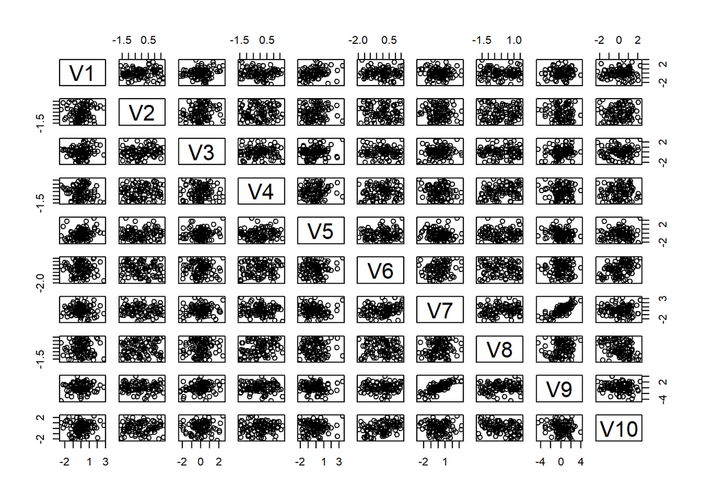

```r
syndata <- SyntheticData(NumOfObs=NumOfObs/10,
                         NumOfCorFeatures=NumOfCorFeatures/4,
                         randomToCorrelRatio=0,
                         pOfnoZero=0.35,
                         noiseLevel=0.2)

plot(syndata$data)
```

```r
print(syndata$rotMatrix)
```

```
#>     La_V1 La_V2      La_V3 La_V4      La_V5 La_V6      La_V7 La_V8      La_V9
#> V1      1     0 -0.2000000     0 -0.2808729     0  0.0000000     0  0.0000000
#> V2      0     1 -0.2703717     0  0.0000000     0  0.0000000     0  0.0000000
#> V3      0     0  1.0000000     0  0.0000000     0  0.0000000     0  0.0000000
#> V4      0     0  0.0000000     1  0.0000000     0  0.0000000     0  0.0000000
#> V5      0     0  0.0000000     0  1.0000000     0  0.0000000     0  0.0000000
#> V6      0     0  0.0000000     0  0.0000000     1 -0.4807738     0  0.0000000
#> V7      0     0  0.0000000     0  0.0000000     0  1.0000000     0 -0.8658924
#> V8      0     0  0.0000000     0  0.0000000     0  0.0000000     1  0.0000000
#> V9      0     0  0.0000000     0  0.0000000     0 -0.2000000     0  1.0000000
#> V10     0     0  0.0000000     0  0.0000000     0  0.0000000     0  0.2000000
#>         La_V10
#> V1   0.0000000
#> V2   0.0000000
#> V3   0.0000000
#> V4   0.0000000
#> V5   0.0000000
#> V6  -0.4821552
#> V7   0.0000000
#> V8   0.2000000
#> V9   0.0000000
#> V10  1.0000000
```

### 1.1.1 ILAA

```r
IdeT <- ILAA(syndata$data,thr=thr,verbose=TRUE,bootstrap=30)
```

fast | LM | V7 V6 V1 V3 V2 V1 V2 V3 V4 V5 V6 0.4 0.1 0.2 0.5 0.3 0.8

Included: 10 , Uni p: 0.015 , Base Size: 5 , Rcrit: 0.2171427

1 <R=0.641,thr=0.700>, Top: 1< 1 >Fa= 1,<|><>Tot Used: 2 , Added: 1 , Zero Std: 0 , Max Cor: 0.423

2 <R=0.423,thr=0.400>, Top: 1< 1 >Fa= 2,<|><>Tot Used: 4 , Added: 1 , Zero Std: 0 , Max Cor: 0.338

3 <R=0.338,thr=0.400>

[ 3 ], 0.210433 Decor Dimension: 4 Nused: 4 . Cor to Base: 2 , ABase: 10 , Outcome Base: 0

V1 V2 V3 V4 V5 V8 1 1 1 1 1 1

```r
rmat <- attr(IdeT,"UPLTM")
print(rmat)
```

[output not shown]

```r
falsedisc <- str_detect(rownames(rmat),"R")
sum(falsedisc)
```

[1] 0

```r
rmat <- rmat[!falsedisc,]
falsedisc <- str_detect(colnames(rmat),"R")
sum(falsedisc)
```

[1] 0

```r
rmat <- rmat[,!falsedisc]

rnrotmat <- syndata$rotMatrix
colnames(rnrotmat) <- str_remove_all(colnames(rnrotmat),"La_")
trueUsedFeatures <- rnrotmat != 0
trueUsedFeatures <- 1*(trueUsedFeatures | t(trueUsedFeatures))

rnrmat <- rmat
colnames(rnrmat) <- str_remove_all(colnames(rnrmat),"La_")
detectedFeatures <- rnrmat != 0
detectedFeatures <- 1*(detectedFeatures | t(detectedFeatures))

aux <- detectedFeatures
detectedFeatures <- 0*trueUsedFeatures
for (rn in rownames(aux))
{
  for (cn in colnames(aux))
  {
    detectedFeatures[rn,cn] <- aux[rn,cn];
  }
}
diag(detectedFeatures) <- 1.0

pairAsosTable <- NULL
for (rn in c(1:(nrow(trueUsedFeatures)-1)))
{
  for (cn in c((rn+1):ncol(trueUsedFeatures)))
  {
    pairAsosTable <- rbind(pairAsosTable,c(detectedFeatures[rn,cn],trueUsedFeatures[rn,cn]))
  }
}
colnames(pairAsosTable) <- c("Estimated","True")
pairAsosTable <- as.data.frame(pairAsosTable)
pander::pander(table(pairAsosTable))
```

|  | 0 | 1 |
| --- | --- | --- |
| **0** | 37 | 6 |
| **1** | 0 | 2 |

```r
npairAsosTable <- as.data.frame(pairAsosTable==0)
pair_Analysis <- epiR::epi.tests(table(npairAsosTable))
sen <- pair_Analysis$detail[3,2]
spe <- pair_Analysis$detail[4,2]
acc <- pair_Analysis$detail[5,2]

sen <- sum((pairAsosTable$Estimated==pairAsosTable$True)&pairAsosTable$True)/sum(pairAsosTable$True)
spe <- sum((pairAsosTable$Estimated==pairAsosTable$True)&(pairAsosTable$True==0))/sum(pairAsosTable$True==0)
acc <- sum(pairAsosTable$Estimated==pairAsosTable$True)/nrow(pairAsosTable)
pander::pander(c(Accuracy=acc,Sensitivity=sen,Specificity=spe))
```

| Accuracy | Sensitivity | Specificity |
| --- | --- | --- |
| 0.867 | 0.25 | 1 |

### 1.1.2 Heat map

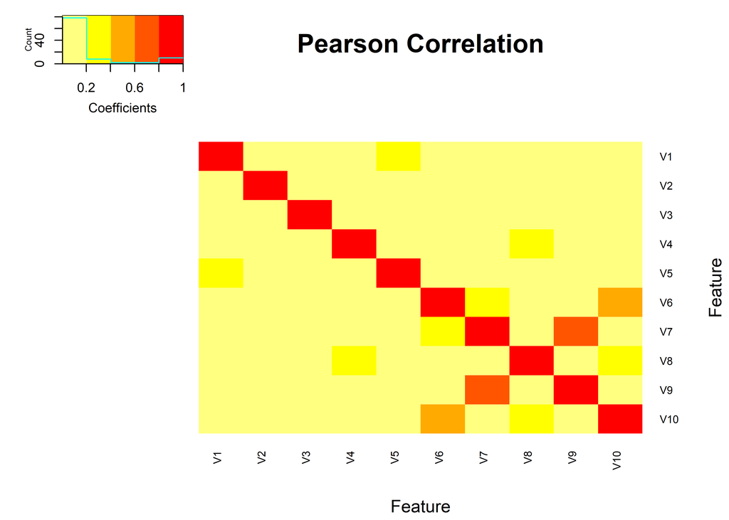

```r
rawCor <- cor(syndata$onlyRotatedData)

  gplots::heatmap.2(abs(rawCor),
                    trace = "none",
                    mar = c(5,5),
                    Rowv = FALSE,
                    Colv = FALSE,
                    col=rev(heat.colors(5)),
                    main = "Pearson Correlation",
                    dendrogram = "none",
                    cexRow = 0.75,
                    cexCol = 0.75,
                    key.title=NA,
                    key.xlab="Coefficients",
                    xlab="Feature", ylab="Feature")
```

### 1.1.3 Heat map true rotation

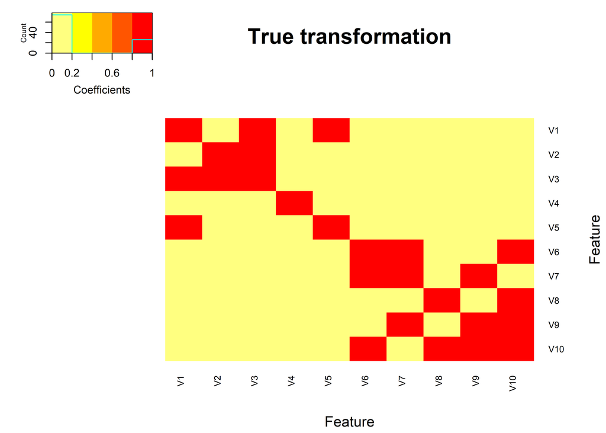

```r
gplots::heatmap.2(trueUsedFeatures,
                    trace = "none",
                    mar = c(5,5),
                    Rowv = FALSE,
                    Colv = FALSE,
                    col=rev(heat.colors(5)),
                    main = "True transformation",
                    dendrogram = "none",
                    cexRow = 0.75,
                    cexCol = 0.75,
                    key.title=NA,
                    key.xlab="Coefficients",
                    xlab="Feature", ylab="Feature")
```

### 1.1.4 Heat map estimated rotation

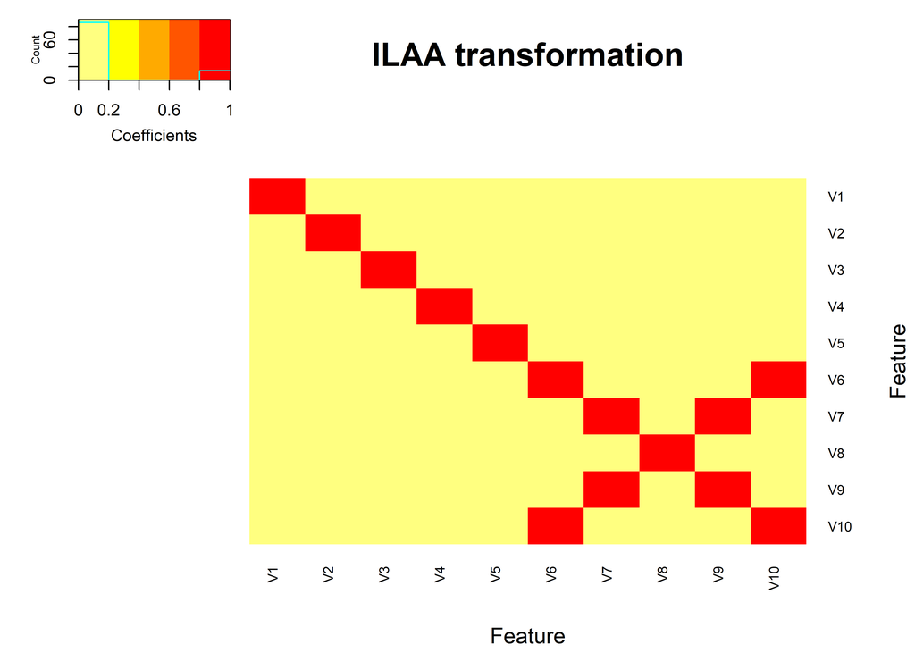

```r
gplots::heatmap.2(detectedFeatures,
                    trace = "none",
                    mar = c(5,5),
                    Rowv = FALSE,
                    Colv = FALSE,
                    col=rev(heat.colors(5)),
                    main = "ILAA transformation",
                    dendrogram = "none",
                    cexRow = 0.75,
                    cexCol = 0.75,
                    key.title=NA,
                    key.xlab="Coefficients",
                    xlab="Feature", ylab="Feature")
```